# Reproducible Research - Week 2, Project

Sam Rickman

27 November 2018

# Assignment instructions

This assignment makes use of data from a personal activity monitoring device. This device collects data at 5 minute intervals through out the day. The data consists of two months of data from an anonymous individual collected during the months of October and November, 2012 and include the number of steps taken in 5 minute intervals each day.

**[Data source](https://d396qusza40orc.cloudfront.net/repdata%2Fdata%2Factivity.zip)**

# Assignment questions and responses

## 1. Code for reading in the dataset and/or processing the data

```r
# Read in URL address and set destination file name data

fileUrl <- "https://d396qusza40orc.cloudfront.net/repdata%2Fdata%2Factivity.zip"
destFileName <- "repdata.zip"

# Download the data if not already downloaded
if(!file.exists(destFileName)){
        download.file(fileUrl, destfile = destFileName, mode = "wb")
}

# Unzip the downloaded file if not already done
if(!dir.exists("repdata")){
        unzip(destFileName, exdir="./repdata")
}

# Read in the data - I am reading in the date and time as character
# For ease of later conversion
repData <- read.csv("./repdata/activity.csv", colClasses = c("numeric", "character", "character"))
```

# 2. Histogram of the total number of steps taken each day

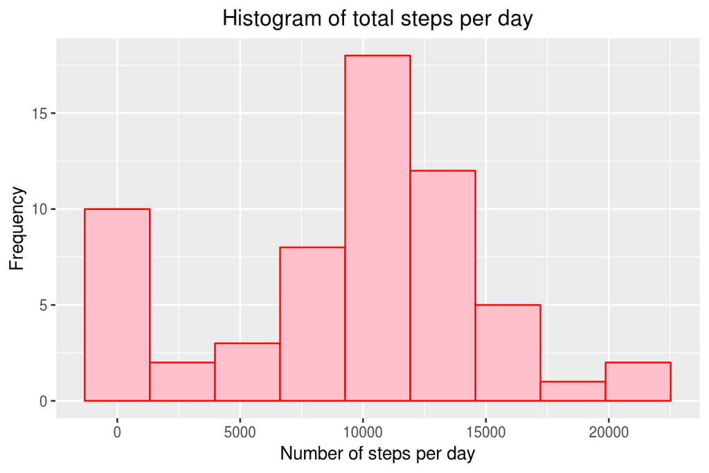

```r
library(ggplot2)
library(lubridate)
# Calculate the daily total number of steps taken
dailyTotals <- tapply(repData$steps, repData$date, sum, na.rm = TRUE)

# Make it a data frame
dailyTotals <- as.data.frame(dailyTotals)

# Take the dates out of the row names and make them a value
dailyTotals$sumOfSteps <- dailyTotals$dailyTotals
dailyTotals$dailyTotals <- rownames(dailyTotals)

# Name the date column something sensible
names(dailyTotals)[1] <- "Date"

# Make the Date class date and the steps class numeric
dailyTotals$Date <- ymd(dailyTotals$Date)
dailyTotals$sumOfSteps <- as.numeric(dailyTotals$sumOfSteps)

dailyHist <- ggplot(data = dailyTotals, aes(x=sumOfSteps)) +
                                        geom_histogram(bins = 9,
                                        color = "red", fill = "pink") +
                                        xlab(element_text("Number of steps per day")) +
                                        ylab(element_text("Frequency")) +
                                        ggtitle(element_text("Histogram of total steps per day")) +
                                        theme(plot.title = element_text(hjust = 0.5))
dailyHist
```

# 3. Calculate and report the mean and median of the total number of steps taken per day

```r
# Mean of number of total number of steps
totalMean <- mean(dailyTotals$sumOfSteps, na.rm = TRUE)

# Median of total number number of steps each day
totalMedian <- median(dailyTotals$sumOfSteps, na.rm = TRUE)

# Output
paste("The mean of steps taken per day is", round(totalMean, 2),
        "and the median of total steps taken per day is", totalMedian, sep = " ")
```

[1] “The mean of steps taken per day is 9354.23 and the median of total steps taken per day is 10395”

# 4. What is the average daily activity pattern?

## Make a time series plot (i.e. type=“l”) of the 5-minute interval (x-axis) and the average number of steps taken, averaged across all days (y-axis)

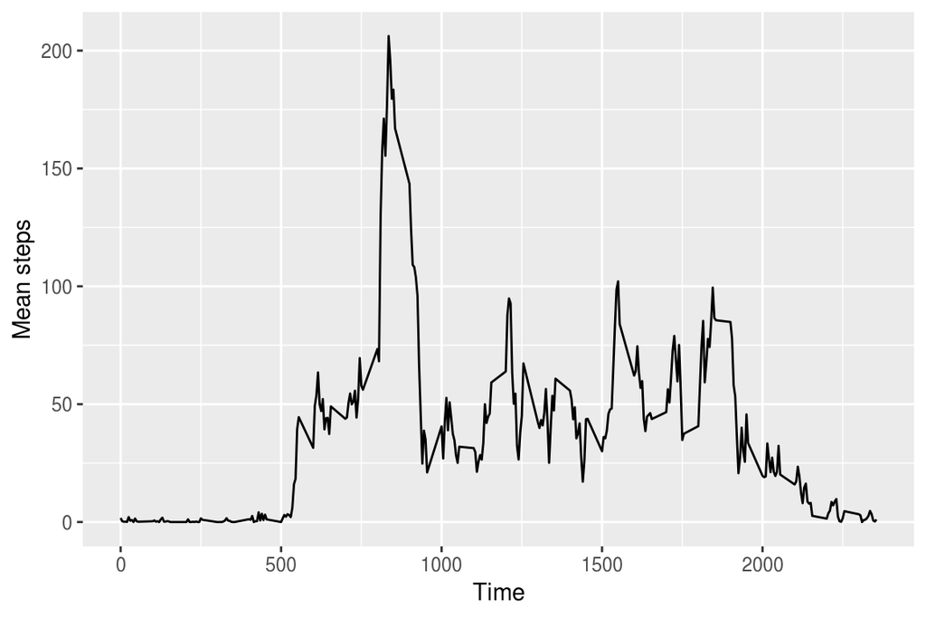

```r
# Calculate the average across each five-minute period:

meanStepsByTime <- tapply(repData$steps, repData$interval, mean, na.rm = TRUE)

# Make it a data frame
meanStepsByTime <- as.data.frame(meanStepsByTime)


# Make rownames a value
meanStepsByTime$meanSteps <- meanStepsByTime$meanStepsByTime
meanStepsByTime$meanStepsByTime <- rownames(meanStepsByTime)


# Rename the Time column
names(meanStepsByTime)[1] <- "Time"

# Make mean steps and time numeric
meanStepsByTime$meanSteps <- as.numeric(meanStepsByTime$meanSteps)

meanStepsByTime$Time <- as.numeric(meanStepsByTime$Time)

timePlot <- ggplot(data = meanStepsByTime, mapping = aes(x = Time, y = meanSteps,
                                                         group = 1)) +
                                                        geom_line() +
                                                        ylab(element_text("Mean steps"))

timePlot
```

## 5. Which 5-minute interval, on average across all the days in the dataset, contains the maximum number of steps?

```r
# Find out which position in the data frame has the maximum number of steps:
rowNum <- which.max(meanStepsByTime$meanSteps)

paste("The five minute period is", meanStepsByTime$Time[rowNum], "to", meanStepsByTime$Time[rowNum]+4, "which has an average of", round(meanStepsByTime$meanSteps[rowNum],2), "steps", sep=" ")
```

```
## [1] "The five minute period is 835 to 839 which has an average of 206.17 steps"
```

# 6. Code to show a strategy for imputing missing values

Note that there are a number of days/intervals where there are missing values (coded as NA). The presence of missing days may introduce bias into some calculations or summaries of the data.

Calculate and report the total number of missing values in the dataset (i.e. the total number of rows with NAs)

```r
# The number of missing values is as below:
sum(is.na(repData$steps))
```

[1] 2304

```r
# Devise a strategy for filling in all of the missing values in the dataset. The strategy does not need to be sophisticated. For example, you could use the mean/median for that day, or the mean for that 5-minute interval, etc.

# Check where the missing values are
missingValueLocations <- is.na(repData$steps)

# Subset so we just have a data frame of missing values
missingValues <- repData[missingValueLocations,]

library(xtable)
# Look at any patterns
missingDates <- table(missingValues$date)
# Format missingDates for printing
missingDates <- xtable(missingDates)
print(missingDates, type="html")
```

|  | V1 |
| --- | --- |
| 2012-10-01 | 288 |
| 2012-10-08 | 288 |
| 2012-11-01 | 288 |
| 2012-11-04 | 288 |
| 2012-11-09 | 288 |
| 2012-11-10 | 288 |
| 2012-11-14 | 288 |
| 2012-11-30 | 288 |

We can see that there are 8 days, each with 288 missing values, i.e. all of them.

It would make sense to populate each of these days with an average day.

We already have a data frame of mean steps by time, so we can use that.

## Create a new dataset that is equal to the original dataset but with the missing data filled in.

```r
# Fill in the missing values in the frame of missing data with the mean steps
missingValues$steps <- rep(meanStepsByTime$meanSteps, 8)

# Then we create an imputed data set first by copying the original one without missing values

imputedData <- repData[!missingValueLocations,]

# Then we can add the (now updated) missing values back in with their new values
imputedData <- rbind(imputedData, missingValues)

# This will have changed the order of the data so let's put it back in date order
library(dplyr)
imputedData <- arrange(imputedData, date)
```

## 7. Make a histogram of the total number of steps taken each day

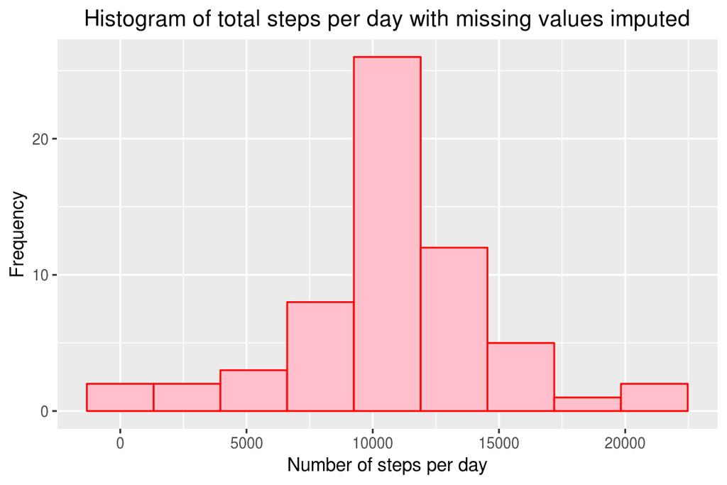

```r
# Let's do this the same way as in the first question:

# Calculate the daily total number of steps taken
dailyTotals <- tapply(imputedData$steps, imputedData$date, sum, na.rm = TRUE)

# Make it a data frame
dailyTotals <- as.data.frame(dailyTotals)

# Take the dates out of the row names and make them a value
dailyTotals$sumOfSteps <- dailyTotals$dailyTotals
dailyTotals$dailyTotals <- rownames(dailyTotals)

# Name the date column something sensible
names(dailyTotals)[1] <- "Date"

# Make the Date class date and the steps class numeric
dailyTotals$Date <- ymd(dailyTotals$Date)
dailyTotals$sumOfSteps <- as.numeric(dailyTotals$sumOfSteps)

dailyHist <- ggplot(data = dailyTotals, aes(x=sumOfSteps)) +
        geom_histogram(bins = 9,
                       color = "red", fill = "pink") +
        xlab(element_text("Number of steps per day")) +
        ylab(element_text("Frequency")) +
        ggtitle(element_text("Histogram of total steps per day with missing values imputed")) +
        theme(plot.title = element_text(hjust = 0.5))
dailyHist
```